# Birth Data: Data cleaning

Liz Lorenzi

8/13/2018

## Cleaning the NC Birth Data

### Checking for missing data

First, we read in the original data set as is, and summarize the data to look for potential missingness and other data problems. There are a few that I spot..

```r
#Read in birth data
o_data <- read.csv("~/Documents/case-studies/data/2011-2016 Vital Files Duke_Herring/Yr1116Birth.csv")
summary(o_data)
```

```
##       YOB            SEX            CORES            CIGPN
##  Min.   :2011   Min.   :1.000   Min.   :  1.00   Min.   : 0.000
##  1st Qu.:2012   1st Qu.:1.000   1st Qu.: 32.00   1st Qu.: 0.000
##  Median :2014   Median :1.000   Median : 57.00   Median : 0.000
##  Mean   :2014   Mean   :1.489   Mean   : 53.51   Mean   : 2.073
##  3rd Qu.:2015   3rd Qu.:2.000   3rd Qu.: 76.00   3rd Qu.: 0.000
##  Max.   :2016   Max.   :9.000   Max.   :100.00   Max.   :99.000
##
##      CIGFN            CIGSN            CIGLN              BWTG
##  Min.   : 0.000   Min.   : 0.000   Min.   : 0.0000   Min.   :   4
##  1st Qu.: 0.000   1st Qu.: 0.000   1st Qu.: 0.0000   1st Qu.:2948
##  Median : 0.000   Median : 0.000   Median : 0.0000   Median :3310
##  Mean   : 1.316   Mean   : 1.033   Mean   : 0.9413   Mean   :3262
##  3rd Qu.: 0.000   3rd Qu.: 0.000   3rd Qu.: 0.0000   3rd Qu.:3640
##  Max.   :99.000   Max.   :99.000   Max.   :99.0000   Max.   :9999
##
##       GEST            PLUR             MAGE           MRACER
##  Min.   :15.00   Min.   : 1.000   Min.   :10.00   Min.   :0.000
##  1st Qu.:38.00   1st Qu.: 1.000   1st Qu.:23.00   1st Qu.:1.000
##  Median :39.00   Median : 1.000   Median :28.00   Median :1.000
##  Mean   :38.55   Mean   : 1.037   Mean   :27.82   Mean   :1.414
##  3rd Qu.:40.00   3rd Qu.: 1.000   3rd Qu.:32.00   3rd Qu.:2.000
##  Max.   :99.00   Max.   :99.000   Max.   :99.00   Max.   :8.000
##
##  MHISP          PARITY
##  C:  1596   Min.   : 1.00
##  M: 64675   1st Qu.: 1.00
##  N:613364   Median : 2.00
##  O:  6455   Mean   : 2.58
##  P:  8233   3rd Qu.: 3.00
##  S: 26932   Max.   :99.00
##  U:   437
```

Skim through the data description excel file provided. You’ll notice that missing information is denoted with a **9** (for sex), **99** for other variables, and **9999** for birthweight. We can read in the data and note the missing values as such (9 appears as a value in the other covariates, so we are not safe to remove it as a missing number globally. Always be sure to check for numeric values that you set with the `na.strings` that it does not mark “missing” the true data inputs). We replace the values with **9** in the `SEX` column with a NA manually using an ifelse statement.

```r
#Read in birth data
o_data <- read.csv("~/Documents/case-studies/data/2011-2016 Vital Files Duke_Herring/Yr1116Birth.csv", na.strings=c(99,9999))
o_data$SEX = ifelse(o_data$SEX==9, NA, o_data$SEX)

#Now remove the missing values (NA)
birth_data <- na.omit(o_data)
```

### Checking for Data Quality

Next, we examine the birthweight data to get a sense of data quality. We can use some clinical information to clean the variables. For example, live births could range from around 20 weeks to 44-45 weeks. Data outside of those ranges are likely errors.

```r
outliers <- which(!(birth_data$GEST >=20 & birth_data$GEST < 45))
#Remove these outliers
birth_data <- birth_data[-outliers,]
```

How do the remaining variables look?

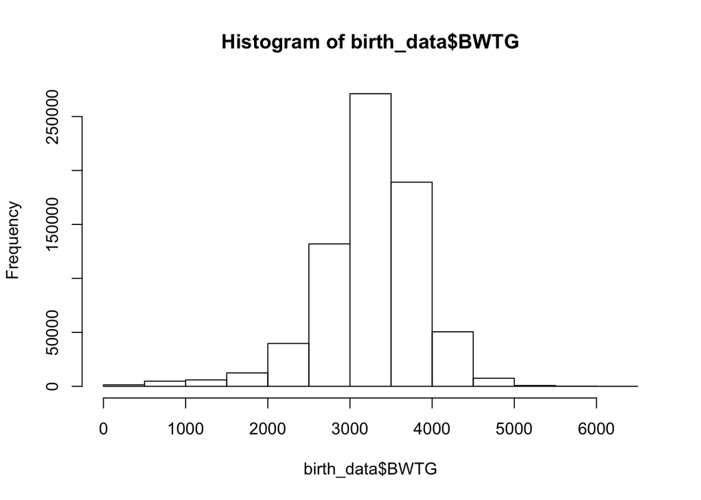

```r
hist(birth_data$BWTG)
```

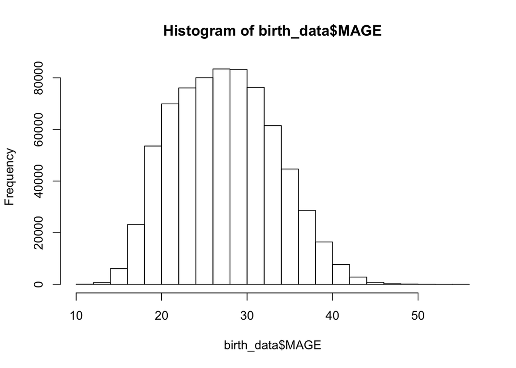

```r
hist(birth_data$MAGE)
```

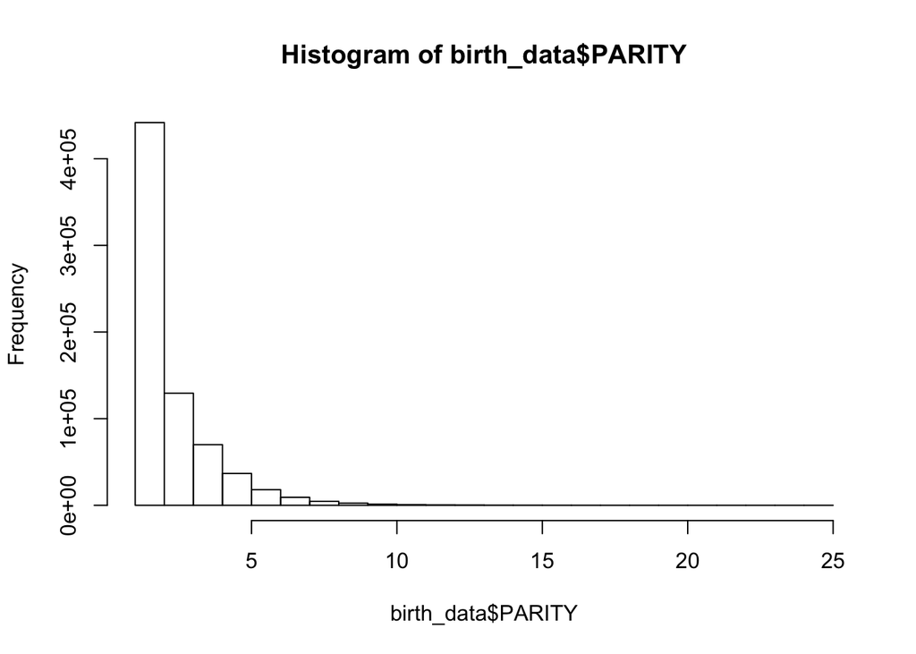

```r
hist(birth_data$PARITY)
```

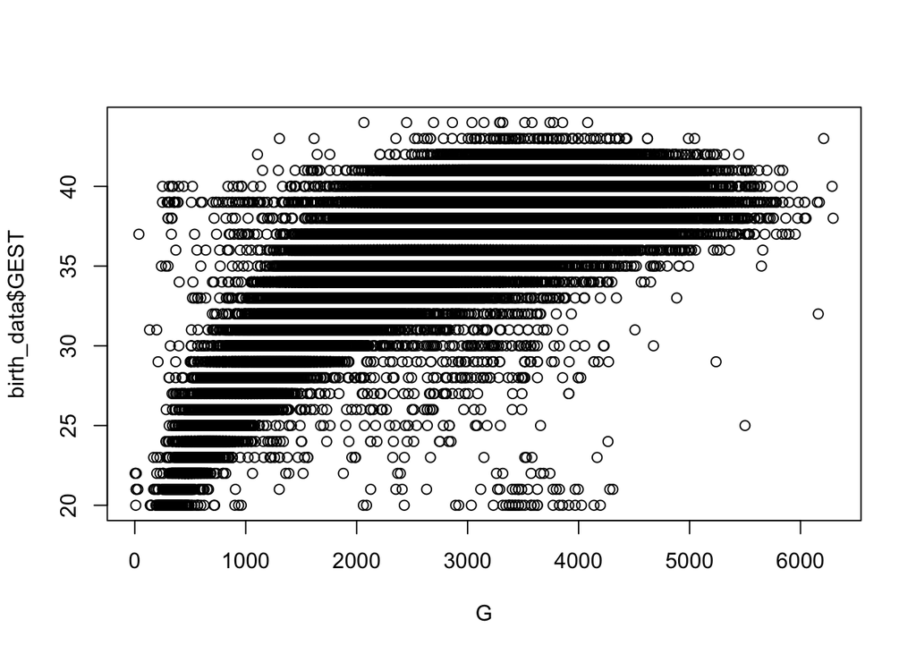

```r
plot(birth_data$BWTG, birth_data$GEST, xlab="G")
```

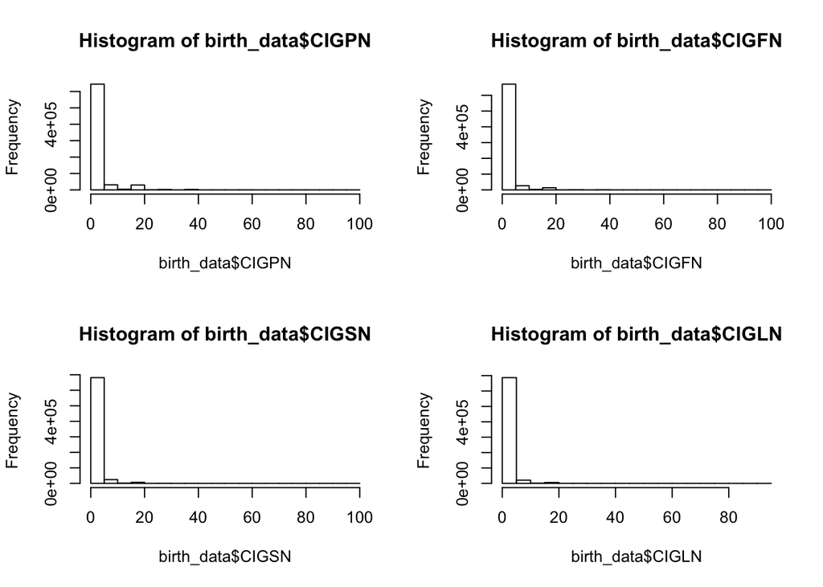

```r
par(mfrow=c(2,2))
hist(birth_data$CIGPN)
hist(birth_data$CIGFN)
hist(birth_data$CIGSN)
hist(birth_data$CIGLN)
```

```r
table(birth_data$MRACER)
```

```
##
##      0      1      2      3      4      5      6      7      8
##  83769 418048 173979  10112   3329    576     93   2112  23135
```

Are any variables showing outliers? Are all groups in binary variables well represented?

To Do: Calculate birth weight z-scores for age and sex. Need to calculate based on reference charts. I am still looking for this information..

Provide additional visualizations of the data to explore further relationships between the variables.